# Power Analysis

## Overview

Power analysis is an important aspect of experimental design. It allows us to determine the sample size required to detect an effect of a given size with a given degree of confidence. Conversely, it allows us to determine the probability of detecting an effect of a given size with a given level of confidence, under sample size constraints. If the probability is unacceptably low, we would be wise to alter or abandon the experiment.

The following **four quantities** have an intimate relationship:

1. sample size
2. effect size
3. significance level = P(Type I error) = probability of finding an effect that is not there
4. power = 1 - P(Type II error) = probability of finding an effect that is there

Given any three, we can determine the fourth.

## Power Analysis in R

The [pwr](http://cran.r-project.org/web/packages/pwr/index.html) package develped by Stéphane Champely, impliments power analysis as outlined by [Cohen (!988)](http://www.amazon.com/Statistical-Power-Analysis-Behavioral-Sciences/dp/0805802835). Some of the more important functions are listed below.

| **function** | **power calculations for** |
| --- | --- |
| **pwr.2p.test** | two proportions (equal n) |
| **pwr.2p2n.test** | two proportions (unequal n) |
| **pwr.anova.test** | balanced one way ANOVA |
| **pwr.chisq.test** | chi-square test |
| **pwr.f2.test** | general linear model |
| **pwr.p.test** | proportion (one sample) |
| **pwr.r.test** | correlation |
| **pwr.t.test** | t-tests (one sample, 2 sample, paired) |
| **pwr.t2n.test** | t-test (two samples with unequal n) |

**For each of these functions, you enter three of the four quantities (effect size, sample size, significance level, power) and the fourth is calculated.**

The significance level defaults to 0.05. Therefore, to calculate the significance level, given an effect size, sample size, and power, use the option "sig.level=NULL".

Specifying an [effect size](http://en.wikipedia.org/wiki/Effect_size) can be a daunting task. ES formulas and Cohen's suggestions (based on social science research) are provided below. Cohen's suggestions should only be seen as very rough guidelines. Your own subject matter experience should be brought to bear.

(To explore confidence intervals and drawing conclusions from samples try [this interactive course on the foundations of inference.)](https://www.datacamp.com/courses/foundations-of-inference)

## t-tests

For t-tests, use the following functions:

**pwr.t.test(n = , d = , sig.level = , power = , type = c("two.sample", "one.sample", "paired"))**

where n is the sample size, d is the effect size, and type indicates a two-sample t-test, one-sample t-test or paired t-test. If you have unequal sample sizes, use

**pwr.t2n.test(n1 = , n2= , d = , sig.level =, power = )**

where n1 and n2 are the sample sizes.

For t-tests, the effect size is assessed as

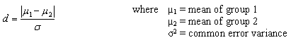

Cohen suggests that d values of 0.2, 0.5, and 0.8 represent small, medium, and large effect sizes respectively.

You can specify alternative="two.sided", "less", or "greater" to indicate a two-tailed, or one-tailed test. A two tailed test is the default.

## ANOVA

For a one-way analysis of variance use

**pwr.anova.test(k = , n = , f = , sig.level = , power = )**

where k is the number of groups and n is the common sample size in each group.

For a one-way ANOVA effect size is measured by f where

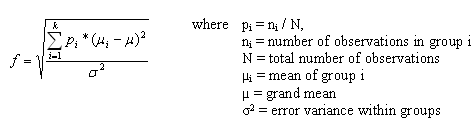

Cohen suggests that f values of 0.1, 0.25, and 0.4 represent small, medium, and large effect sizes respectively.

## Correlations

For correlation coefficients use

**pwr.r.test(n = , r = , sig.level = , power = )**

where n is the sample size and r is the correlation. We use the population correlation coefficient as the effect size measure. Cohen suggests that r values of 0.1, 0.3, and 0.5 represent small, medium, and large effect sizes respectively.